# Plotting options

Arnaud Wolfer

2017-12-30

The `santaR` package is designed for the detection of significantly altered time trajectories between study groups, in short time-series.

As the visualisation of significantly altered time-trajectories is critical to the interpretation of the process under study, this vignette will detail the plotting options present in `santaR`. `santaR_plot()` returns a `ggplot2 plotObject` that can be further modified using `ggplot2` grammar.

## Plotting options

First we can analyse a subset of data using `santaR_auto_fit()`, returning a list of *SANTAObj*.

```r
library(santaR)

# Load a subset of the example data
tmp_data  <- acuteInflammation$data[,1:6]
tmp_meta  <- acuteInflammation$meta

# Analyse data, with confidence bands and p-value
res_acuteInf_df5 <- santaR_auto_fit(inputData=tmp_data, ind=tmp_meta$ind, time=tmp_meta$time, group=tmp_meta$group, df=5, ncores=0, CBand=TRUE, pval.dist=FALSE)
```

```
## Input data generated: 0.02 secs
```

```
## Spline fitted: 0.09 secs
```

```
## ConfBands done: 10.07 secs
```

```
## total time: 10.18 secs
```

### Basic plot

Each variable can be accessed either by its list position or variable name:

```r
# Default plot
# individual points, individual trajectories, group mean curves and confidence bands

  # access by list position
santaR_plot(res_acuteInf_df5[[5]])
```

[output not shown]

```r
  # access by variable name
santaR_plot(res_acuteInf_df5$var_5)
```

[output not shown]

The individual points, trajectories, group mean curves and confidence bands can be turned on or off:

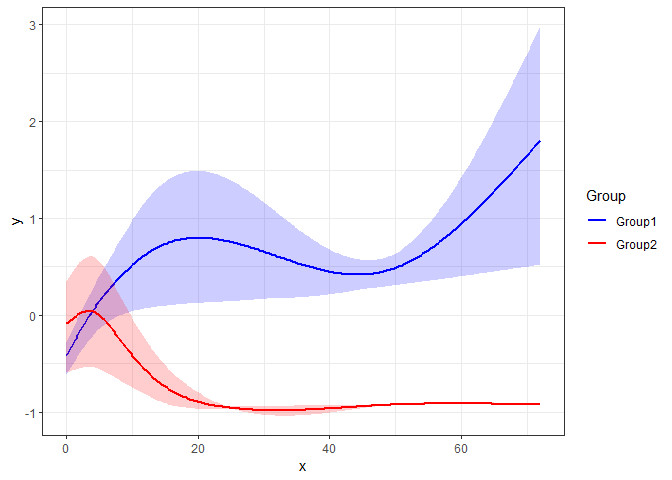

```r
  # only groupMeanCurve
santaR_plot(res_acuteInf_df5$var_5, showIndPoint=FALSE, showIndCurve=FALSE, showGroupMeanCurve=TRUE, showConfBand=TRUE)
```

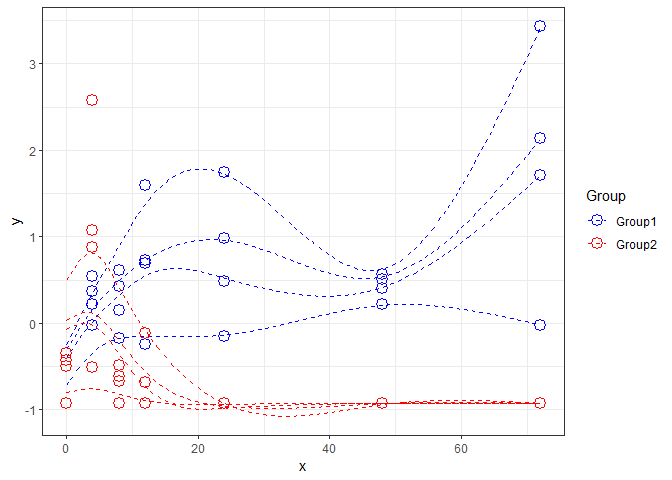

```r
  # only Individuals
santaR_plot(res_acuteInf_df5$var_5, showIndPoint=TRUE, showIndCurve=TRUE, showGroupMeanCurve=FALSE, showConfBand=FALSE)
```

```r
  # add confidence bands (only available if  previously calculated)
santaR_plot(res_acuteInf_df5$var_5, showIndPoint=TRUE, showIndCurve=TRUE, showGroupMeanCurve=TRUE, showConfBand=TRUE)
```

[output not shown]

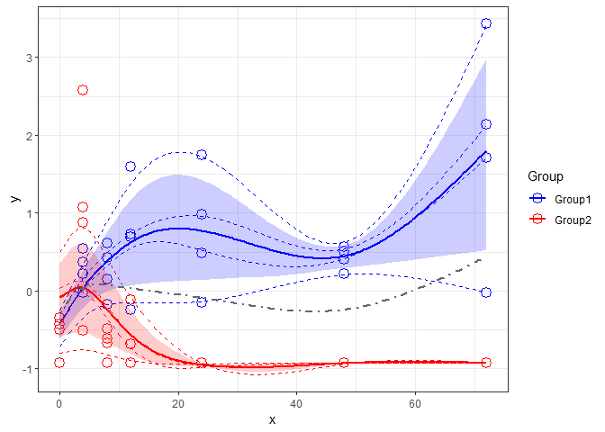

```r
  # add a totalMeanCurve (grey)
santaR_plot(res_acuteInf_df5$var_5, showTotalMeanCurve=TRUE )
```

### Adding options

Title and axis can be altered to suit the analysis:

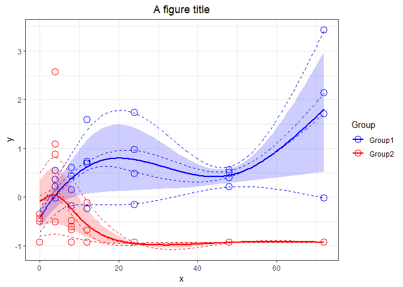

```r
  # add title
santaR_plot(res_acuteInf_df5$var_5, title='A figure title')
```

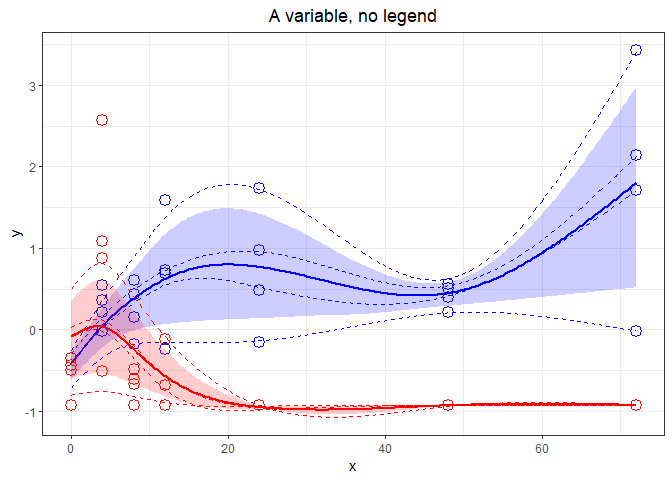

```r
  # remove the legend
santaR_plot(res_acuteInf_df5$var_5, title='A variable, no legend', legend=FALSE)
```

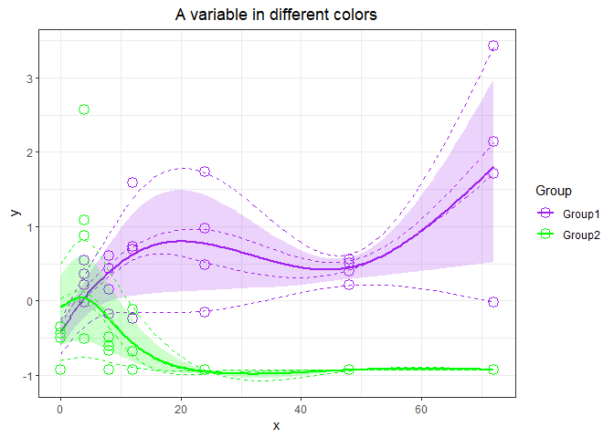

```r
  # force purple and green color
santaR_plot(res_acuteInf_df5$var_5,  title='A variable in different colors', colorVect = c('purple','green'))
```

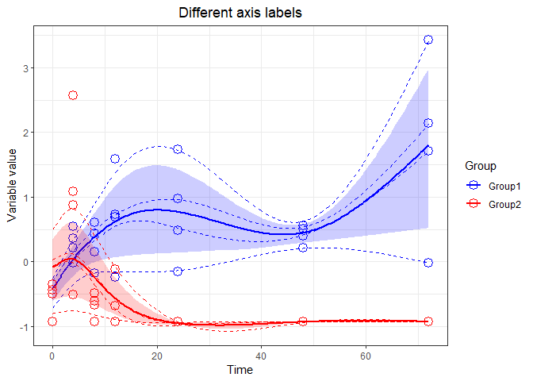

```r
# Default colors are in order: "blue", "red", "green", "orange", "purple", "seagreen", "darkturquoise", "violetred", "saddlebrown", "black"

  # add x and y labels
santaR_plot(res_acuteInf_df5$var_5, title='Different axis labels', xlab='Time', ylab='Variable value')
```

### Updating plot with ggplot2 grammar

`santaR_plot()` returns a `ggplot2 plotObject` that can be modified using all the range of `ggplot2` grammar:

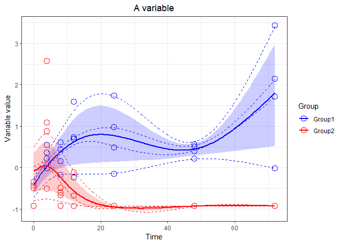

```r
library(ggplot2)

  # add x and y labels by adding it outside the plotting function [not useful but shows that any ggplot command can be added to the plot]
santaR_plot(res_acuteInf_df5$var_5, title='A variable') + xlab('Time') + ylab('Variable value')
```

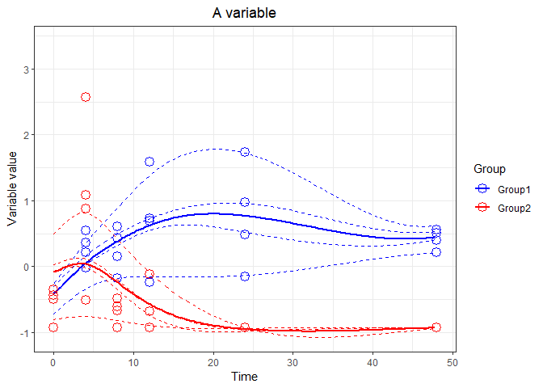

```r
  # Constrain the x axis (will remove points and raise warnings)
santaR_plot(res_acuteInf_df5$var_5, showConfBand=FALSE, title='A variable', xlab='Time', ylab='Variable value') + xlim(0,48)
```

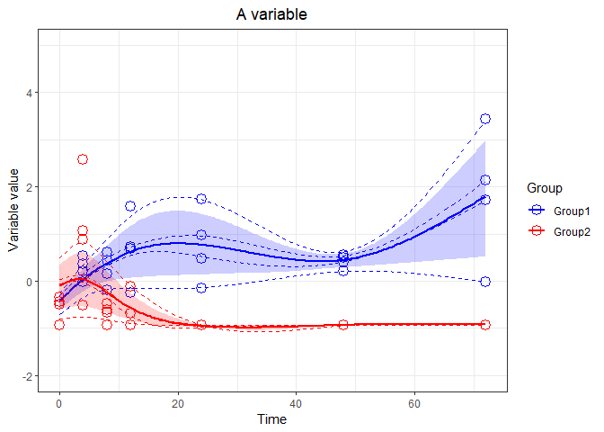

```r
  # Looser y limits
santaR_plot(res_acuteInf_df5$var_5, title='A variable', xlab='Time', ylab='Variable value') + ylim(-2,5)
```

### Multiplots

Plots can be stored in a variables and combined in multiplots using `gridExtra grid.arrange()`:

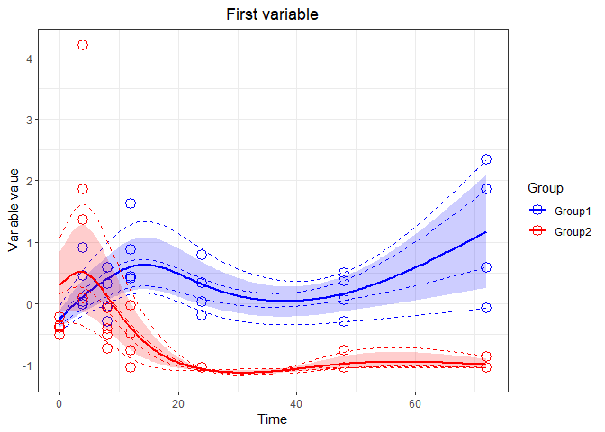

```r
library(gridExtra)

  # store plot in a variable, plot multiple variables...
p1 <- santaR_plot(res_acuteInf_df5$var_3, title='First variable', xlab='Time', ylab='Variable value')
plot(p1)
```

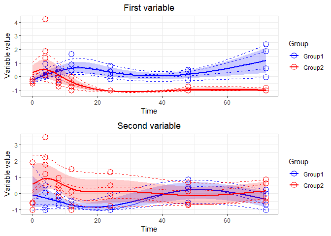

```r
p2 <- santaR_plot(res_acuteInf_df5$var_4, title='Second variable', xlab='Time', ylab='Variable value')

  # multiplot
grid.arrange(p1, p2)
```

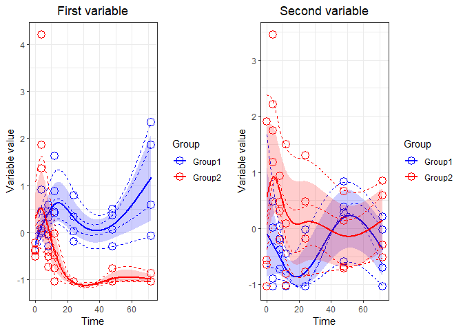

```r
  # force them side by side
grid.arrange(p1, p2, ncol=2)
```

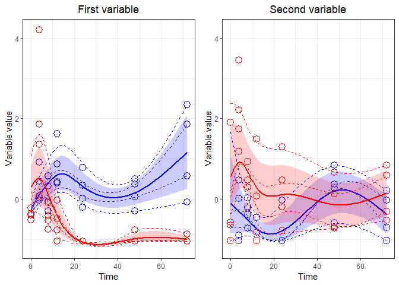

```r
  # Force both plots on the same y limits (remove legend from plots)
p1 <- santaR_plot(res_acuteInf_df5$var_3, title='First variable', xlab='Time', ylab='Variable value', legend=FALSE)
p2 <- santaR_plot(res_acuteInf_df5$var_4, title='Second variable', xlab='Time', ylab='Variable value', legend=FALSE)

p1 <- p1 + ylim(-1.2, 4.2)
p2 <- p2 + ylim(-1.2, 4.2)

grid.arrange(p1, p2, ncol=2 )
```

## See Also

- Getting Started with santaR
- How to prepare input data for santaR
- santaR theoretical background
- Graphical user interface use
- Automated command line analysis
- Selecting an optimal number of degrees of freedom
- Advanced command line options